# MUSA508: Predicting Bike Share Demand in Philadelphia

Jenna Epstein

11/12/2020

# Introduction

In recent years, bike share programs have become a prominent form of micro-mobility in cities. While some dock-less programs have emerged, several cities still rely on docking station networks as points for riders to pick-up and drop-off bikes. For commuters and students, bikes provide an alternative, sustainable form of transit that provides flexibility. These bike share programs, however, are not useful if the number of bikes at each dock does not meet the demand of riders. Especially during peak commute times, this could have negative implications on the customer base, ranging from simple frustrations, to verbal complaints, to complete abandonment of program membership. It is thus in the best interest of bike share operators to accommodate demand of their customers, and rebalance the bike share bikes accordingly.

This analysis looks at bike share ridership in Philadelphia in August 2018 to forecast space/time demand for bike pickups. Data is provided by Indego, the bike share program in the city. By using a summer month, when weather is relatively pleasant and there are no holidays affecting typical transit and commute patterns, the goal is for it to be more generalizable to bike share demand in other months.

To meet bike share demand in Philadelphia, I envision a plan to specifically focus on meeting the demands of commuters in the morning and evening. This will require deployment of fleet vehicles to reallocate the bikes across popular docking stations, ensuring that there are enough bikes before the morning and evening rushes. In summer months, customers may want to ride to their places of work during earlier or later hours when the temperature is lower. This will impact the scheduling for Indego truck drivers, and likely require some coordination with planners or even the city to figure out the most optimal routes for large vehicles to drive on.

The development of an algorithm to help predict bike share demand is a key piece to help inform Indego’s operational plans for resource allocation and how to maximize efficiency. While there may be alternate ways of gauging demand from frequent riders - like asking customers to indicate future trips in the Indego app - the company should not rely on user input and self-reporting. Leveraging the existing data to predict for future demand would provide greater accuracy and confidence for Indego as they spend time and resources for re-balancing.

NOTE: The year 2018 is selected due to availability of US Census Bureau, American Community Survey estimates (they are only accessible through 2018 via the API)

```r
# load libraries, functions, and palettes

library(tidyverse)
library(sf)
library(lubridate)
library(tigris)
library(tidycensus)
library(viridis)
library(riem)
library(gridExtra)
library(knitr)
library(kableExtra)
library(jtools)
library(gganimate)
library(gifski)

plotTheme <- theme(
  plot.title =element_text(size=12),
  plot.subtitle = element_text(size=8),
  plot.caption = element_text(size = 6),
  axis.text.x = element_text(size = 10, angle = 45, hjust = 1),
  axis.text.y = element_text(size = 10),
  axis.title.y = element_text(size = 10),
  # Set the entire chart region to blank
  panel.background=element_blank(),
  plot.background=element_blank(),
  #panel.border=element_rect(colour="#F0F0F0"),
  # Format the grid
  panel.grid.major=element_line(colour="#D0D0D0",size=.2),
  axis.ticks=element_blank())

mapTheme <- function(base_size = 12) {
  theme(
    text = element_text( color = "black"),
    plot.title = element_text(size = 13,colour = "black"),
    plot.subtitle=element_text(face="italic"),
    plot.caption=element_text(hjust=0),
    axis.ticks = element_blank(),
    panel.background = element_blank(),axis.title = element_blank(),
    axis.text = element_blank(),
    axis.title.x = element_blank(),
    axis.title.y = element_blank(),
    panel.grid.minor = element_blank(),
    panel.border = element_rect(colour = "black", fill=NA, size=2),
    strip.text.x = element_text(size = 14))}

palette5 <- c("#eff3ff","#bdd7e7","#6baed6","#3182bd","#08519c")
palette4 <- c("#D2FBD4","#92BCAB","#527D82","#123F5A")
palette2 <- c("#238A8DFF","#404788FF")
palette5viridis <- c("#FDE725FF", "#55c667ff", "#238A8DFF", "#404788FF", "#440154FF")

q5 <- function(variable) {as.factor(ntile(variable, 5))}

# Helper Functions
qBr <- function(df, variable, rnd) {
  if (missing(rnd)) {
    as.character(quantile(round(df[[variable]],0),
                          c(.01,.2,.4,.6,.8), na.rm=T))
  } else if (rnd == FALSE | rnd == F) {
    as.character(formatC(quantile(df[[variable]]), digits = 3),
                          c(.01,.2,.4,.6,.8), na.rm=T)
  }
}
```

# Import Data

New variables are created also to associate each trip’s start time with an interval of 15 minutes and of 60 minutes. Week and day of the week (dotw) variables are also created at this time based on these new intervals.

Data from the US Census Bureau’s American Community Survey is loaded at this time, and some socioeconomic variables `Percent_White`, `Mean_Commute_Time`, and `Percent_Taking_Public_Trans` are created to use later in the analysis. The Census data is then joined to the bike trips data.

Additionally, the weather-related data is loaded in for Philadelphia during this designated month of August 2018. Data for precipitation, wind speed, and temperature comes from the station at the Philadelphia International Airport.

```r
bikeTrips <- read.csv("indego-trips-2018-q3.csv", na.strings=c("", "NA")) %>%
  filter(str_detect(start_time,"2018-08")) %>%
   tidyr::drop_na()

bikeTrips2 <- bikeTrips %>%
  mutate(interval60 = floor_date(ymd_hms(start_time), unit = "hour"),
         interval15 = floor_date(ymd_hms(start_time), unit = "15 mins"),
         week = week(interval60),
         dotw = wday(interval60, label=TRUE))

phillyCensus <-
  get_acs(geography = "tract",
          variables = c("B01003_001", "B19013_001",
                        "B02001_002", "B08013_001",
                       "B08012_001", "B08301_001",
                        "B08301_010", "B01002_001"),
          year = 2018,
          survey = "acs5",
          state = "PA",
          county = "Philadelphia",
          geometry = T,
          output = "wide",
          cb=F) %>%
  rename(Total_Pop =  B01003_001E,
         Med_Inc = B19013_001E,
         Med_Age = B01002_001E,
         White_Pop = B02001_002E,
         Travel_Time = B08013_001E,
         Num_Commuters = B08012_001E,
         Means_of_Transport = B08301_001E,
         Total_Public_Trans = B08301_010E) %>%
  select(Total_Pop, Med_Inc, White_Pop, Travel_Time,
         Means_of_Transport, Total_Public_Trans,
         Med_Age,
         GEOID, geometry) %>%
  mutate(Percent_White = White_Pop / Total_Pop,
         Mean_Commute_Time = Travel_Time / Total_Public_Trans,
         Percent_Taking_Public_Trans = Total_Public_Trans / Means_of_Transport)

phillyTracts <-
  phillyCensus %>%
  as.data.frame() %>%
  distinct(GEOID, .keep_all = TRUE) %>%
  select(GEOID, geometry) %>%
  st_sf
```

```r
bikeTrips_census <- st_join(bikeTrips2 %>%
          filter(is.na(start_lon) == FALSE &
                   is.na(start_lat) == FALSE &
                   is.na(end_lat) == FALSE &
                   is.na(end_lon) == FALSE) %>%
          st_as_sf(., coords = c("start_lon", "start_lat"), crs = 4326),
        phillyTracts %>%
          st_transform(crs=4326),
        join=st_intersects,
              left = TRUE) %>%
rename(Origin.Tract = GEOID) %>%
  mutate(start_lon = unlist(map(geometry, 1)),
         start_lat = unlist(map(geometry, 2)))%>%
  as.data.frame() %>%
  select(-geometry)%>%
  st_as_sf(., coords = c("end_lon", "end_lat"), crs = 4326) %>%
  st_join(., phillyTracts %>%
            st_transform(crs=4326),
          join=st_intersects,
          left = TRUE) %>%
  rename(Destination.Tract = GEOID)  %>%
  mutate(end_lon = unlist(map(geometry, 1)),
         end_lat = unlist(map(geometry, 2)))%>%
  as.data.frame() %>%
  select(-geometry)
```

```r
weather.Panel <-
  riem_measures(station = "PHL", date_start = "2018-08-01", date_end = "2018-09-01") %>%
  dplyr::select(valid, tmpf, p01i, sknt)%>%
  replace(is.na(.), 0) %>%
    mutate(interval60 = ymd_h(substr(valid,1,13))) %>%
    mutate(week = week(interval60),
           dotw = wday(interval60, label=TRUE)) %>%
    group_by(interval60) %>%
    summarize(Temperature = max(tmpf),
              Precipitation = sum(p01i),
              Wind_Speed = max(sknt)) %>%
    mutate(Temperature = ifelse(Temperature == 0, 42, Temperature))
```

# Data Wrangling and Initial Exploration

Now that all of the data is loaded, the time and frequency components are explored.

This graph shows the bike share trips per hour. The pattern appears consistent - the line peaks and troughs likely correspond to trips in the day versus in the night. There are also lower periods during the weekends.

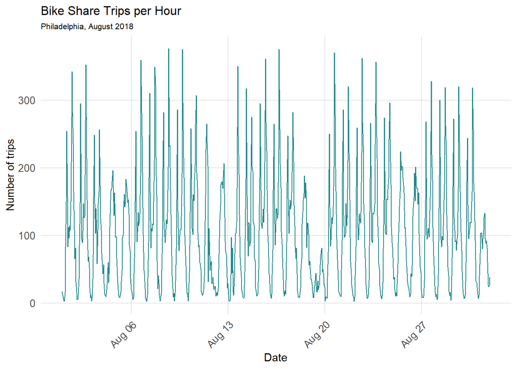

```r
ggplot(bikeTrips_census %>%
         group_by(interval60) %>%
         tally())+
  geom_line(aes(x = interval60, y = n, color="color"))+
        scale_colour_manual(values = palette2) +
  labs(title="Bike Share Trips per Hour",
  subtitle = "Philadelphia, August 2018",
       x="Date",
       y="Number of trips")+
  plotTheme + theme(legend.position = "none")
```

To delve into this further, these histograms show the mean number of hourly trips per bike share station, grouped by time of day: Morning Rush, Mid-Day, Evening, and Overnight. The long tail of the distribution for the evening rush shows that there is more variation in when people take bike trips. This is likely due to different working hours and variation in commutes. There are fewer trips mid-day, which makes sense given that it is during typical work hours for many people in the city. Overnight has the tightest distribution with very few trips, which is expected.

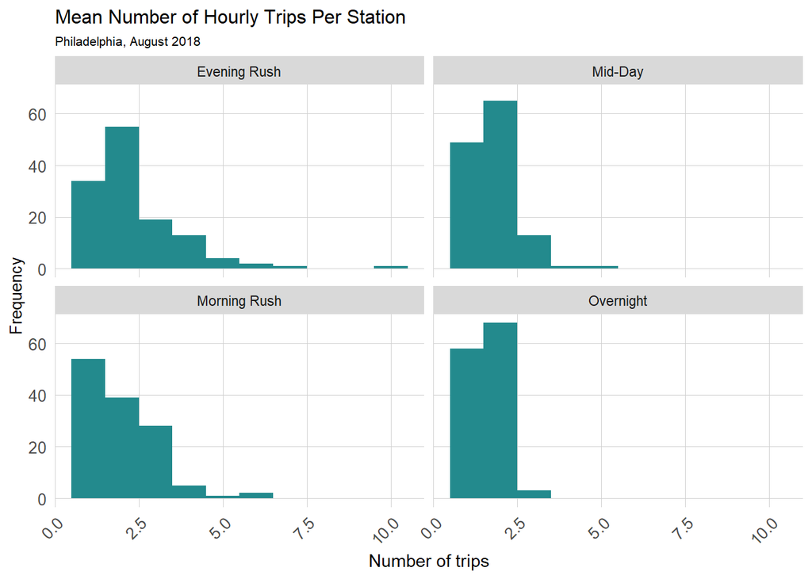

```r
bikeTrips_census %>%
        mutate(time_of_day = case_when(hour(interval60) < 7 | hour(interval60) > 18 ~ "Overnight",
                                 hour(interval60) >= 7 & hour(interval60) < 10 ~ "Morning Rush",
                                 hour(interval60) >= 10 & hour(interval60) < 15 ~ "Mid-Day",
                                 hour(interval60) >= 15 & hour(interval60) <= 18 ~ "Evening Rush"))%>%
         group_by(interval60, start_station, time_of_day) %>%
         tally()%>%
  group_by(start_station, time_of_day)%>%
  summarize(mean_trips = mean(n))%>%
  ggplot()+
  geom_histogram(aes(mean_trips), binwidth = 1, fill="#238A8DFF")+
  labs(title="Mean Number of Hourly Trips Per Station",
  subtitle="Philadelphia, August 2018",
       x="Number of trips",
       y="Frequency")+
  facet_wrap(~time_of_day)+
  plotTheme
```

This chart shows number of trips for each passholder type. Indego30, which provides a 30-day pass for $17 pass, is by far the most popular type. It provides umlimited 60-minute rides, with only 15 cents per minute for rides over that 60 minute period. The company says that this is a popular option for both residents and students in the city.

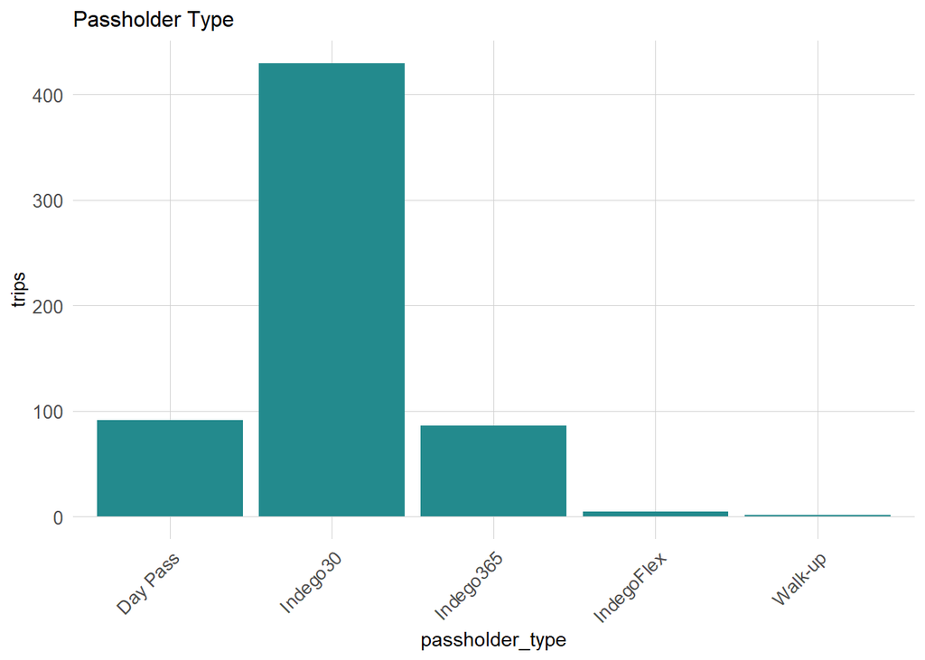

```r
bikeTrips_census %>%
  group_by(passholder_type, start_station) %>%
         tally()%>%
    group_by(start_station, passholder_type)%>%
 summarize(trips = sum(n))%>%
  ggplot(aes(passholder_type, trips)) +
     geom_bar(stat = "summary", fill="#238A8DFF") +
    labs(title = "Passholder Type")+
  plotTheme
```

This plot shows trips by trip type category (one way versus round trip). One way trips are more popular than round trip rides. This makes sense with riders who use the bikes to travel to and from work or school, with several hours in between.

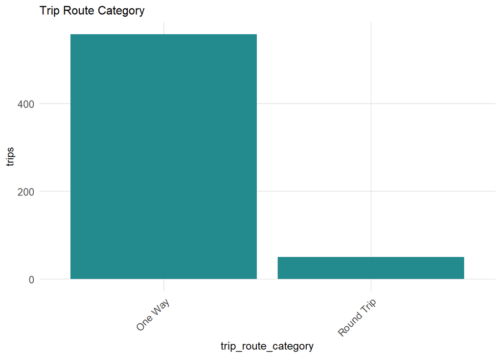

```r
bikeTrips_census %>%
  group_by(trip_route_category, start_station) %>%
         tally()%>%
    group_by(start_station, trip_route_category)%>%
 summarize(trips = sum(n))%>%
  ggplot(aes(trip_route_category, trips)) +
     geom_bar(stat = "summary", fill="#238A8DFF") +
    labs(title = "Trip Route Category")+
  plotTheme
```

The first plot below breaks down the bike share trips by hour, for each day of the week. There are peaks in the morning and the in evening, consistent with typical commuting patterns.

The second plot shows weekdays compared to weekend days (Saturday and Sunday). The weekend days do not have the same peaks as the weekdays do, indicating that fewer people ride bikes according to weekday patterns on the weekend. There is clearly still bike ridership over the weekends, however, especially around mid-day.

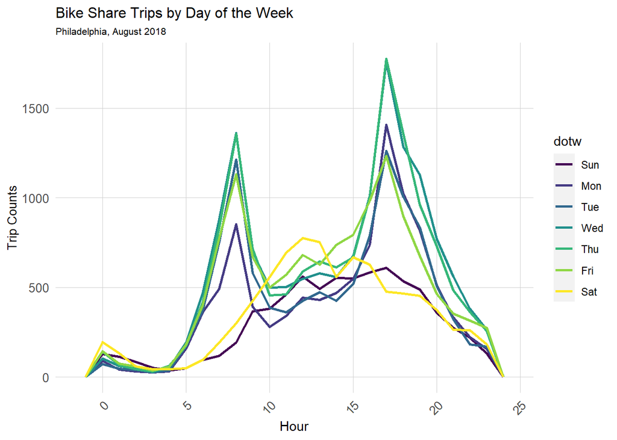

```r
ggplot(bikeTrips_census %>% mutate(hour = hour(start_time)))+
     geom_freqpoly(aes(hour, color = dotw), binwidth = 1, size=1)+
  labs(title="Bike Share Trips by Day of the Week",
  subtitle="Philadelphia, August 2018",
       x="Hour",
       y="Trip Counts")+
     plotTheme
```

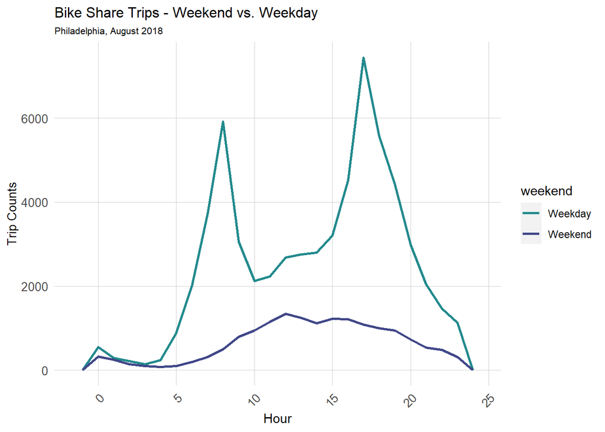

```r
ggplot(bikeTrips_census %>%
         mutate(hour = hour(start_time),
                weekend = ifelse(dotw %in% c("Sun", "Sat"), "Weekend", "Weekday")))+
     geom_freqpoly(aes(hour, color = weekend), binwidth = 1, size=1)+
  scale_colour_manual(values = palette2) +
  labs(title="Bike Share Trips - Weekend vs. Weekday",
  subtitle="Philadelphia, August 2018",
       x="Hour",
       y="Trip Counts")+
     plotTheme
```

This small multiple map series visually shows the spatial distribution of bike share trips per hour, by station. The weekday maps compared to weekend maps show greater number of trips, illustrated by the darker colors. The commute rushes appear to have more dark stations indicating more trips, but the one most pronounced is the evening rush. At a quick visual glance, it is clear that the stations from which people start their trips are concentrated in the center of the city. This indicates that these people likely live within walking distance of these stations.

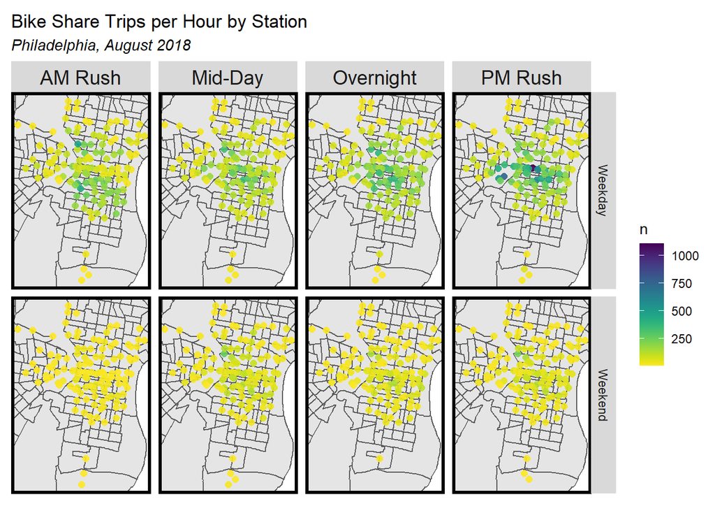

```r
ggplot()+
  geom_sf(data = phillyTracts %>%
          st_transform(crs=4326))+
  geom_point(data = bikeTrips_census %>%
            mutate(hour = hour(start_time),
                weekend = ifelse(dotw %in% c("Sun", "Sat"), "Weekend", "Weekday"),
                time_of_day = case_when(hour(interval60) < 7 | hour(interval60) > 18 ~ "Overnight",
                                 hour(interval60) >= 7 & hour(interval60) < 10 ~ "AM Rush",
                                 hour(interval60) >= 10 & hour(interval60) < 15 ~ "Mid-Day",
                                 hour(interval60) >= 15 & hour(interval60) <= 18 ~ "PM Rush"))%>%
              group_by(start_station, start_lat, start_lon, weekend, time_of_day) %>%
              tally(),
            aes(x=start_lon, y = start_lat, color = n),
            fill = "transparent", alpha = 0.9, size = 2)+
  scale_colour_viridis(direction = -1,
  discrete = FALSE, option = "D")+
  ylim(min(bikeTrips_census$start_lat), max(bikeTrips_census$start_lat))+
  xlim(min(bikeTrips_census$start_lon), max(bikeTrips_census$start_lon))+
  facet_grid(weekend ~ time_of_day)+
  labs(title="Bike Share Trips per Hour by Station",
  subtitle="Philadelphia, August 2018")+
  mapTheme()
```

This series breaks down the trips per station by each day of the week. Wednesday and Thursday appear to have more stations of darker hues, indicating more trips. However, there is also a station on Saturday that also shows more trips (the circle in the darker purple hue). This may have something to do with where the station is located - perhaps near restaurants or a park, or even a high concentration of residences - making it a useful station hub on Saturdays. The overall pattern, though, tells the story that bike share trips are more frequent on weekdays, especially during commute hours. People may choose to ride bikes on the weekend, but the patterns seem less predictable. This all requires further investigation before drawing any conclusions about bike share demand in Philadelphia.

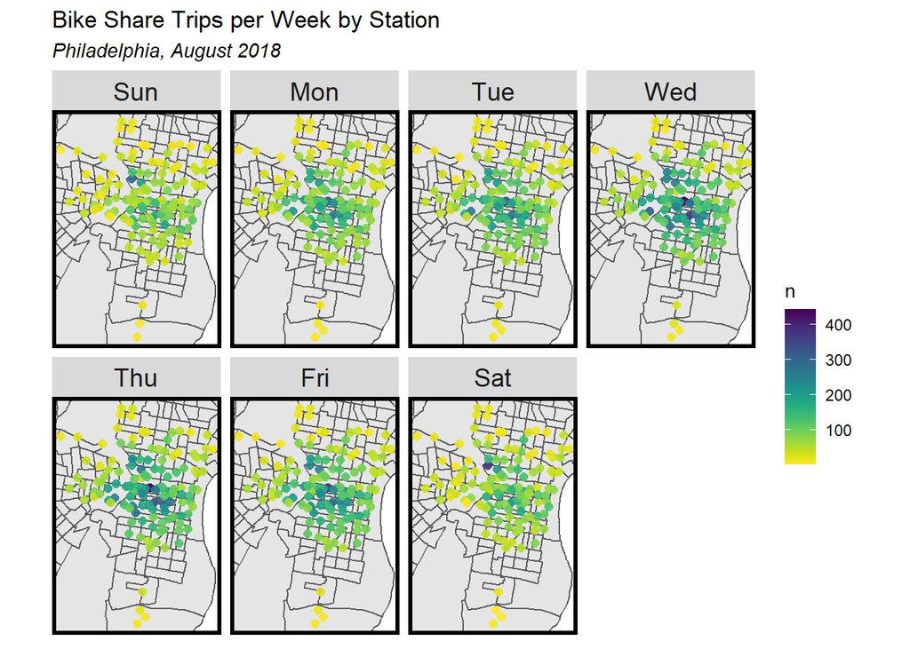

```r
ggplot()+
  geom_sf(data = phillyTracts %>%
          st_transform(crs=4326))+
  geom_point(data = bikeTrips_census %>%
              group_by(start_station, start_lat, start_lon, dotw) %>%
              tally(),
            aes(x=start_lon, y = start_lat, color = n),
            fill = "transparent", alpha = 0.9, size = 2)+
  scale_colour_viridis(direction = -1,
  discrete = FALSE, option = "D")+
  ylim(min(bikeTrips_census$start_lat), max(bikeTrips_census$start_lat))+
  xlim(min(bikeTrips_census$start_lon), max(bikeTrips_census$start_lon))+
  facet_wrap(~dotw, ncol = 4)+
  labs(title="Bike Share Trips per Week by Station",
  subtitle="Philadelphia, August 2018")+
  mapTheme()
```

# Exploratory Analysis

## Create the Space/Time Panel

Before diving deeper into more feature engineering and exploratory analysis, a space/time panel containing an observation for every possible space/time combination is created.

```r
length(unique(bikeTrips_census$interval60)) * length(unique(bikeTrips_census$start_station))
```

```
## [1] 95976
```

```r
study.panel <-
  expand.grid(interval60=unique(bikeTrips_census$interval60),
              start_station = unique(bikeTrips_census$start_station)) %>%
  left_join(., bikeTrips_census %>%
              select(start_station, Origin.Tract, start_lon, start_lat, trip_route_category, passholder_type) %>%
              distinct() %>%
              group_by(start_station) %>%
              slice(1))

#nrow(study.panel)
```

```r
ride.panel <-
  bikeTrips_census %>%
  mutate(Trip_Counter = 1) %>%
  right_join(study.panel) %>%
  group_by(interval60, start_station, Origin.Tract, start_lon, start_lat, trip_route_category, passholder_type) %>%
  summarize(Trip_Count = sum(Trip_Counter, na.rm=T)) %>%
  left_join(weather.Panel) %>%
  left_join(phillyCensus, by = c("Origin.Tract" = "GEOID"))%>%
  ungroup() %>%
  filter(is.na(start_station) == FALSE) %>%
  mutate(week = week(interval60),
         dotw = wday(interval60, label = TRUE)) %>%
  filter(is.na(Origin.Tract) == FALSE) %>%
    mutate(weekend = ifelse(dotw %in% c("Sun", "Sat"), "Weekend", "Weekday")) %>%
   st_sf()
```

## Time Lags

Now that `ride.panel` is created, some feature engineering to create time lag variables will help to understand bike share demand during specific hours of a day (and the day before). No federal holidays occurred in August 2018, so there is no need to control for any additional day-specific lags. the following time lags are created:

- `lagHour`: a time lag of one hour
- `lag2Hours`: a time lag of two hours
- `lag3Hours`: a time lag of three hours
- `lag4Hours`: a time lag of four hours
- `lag12Hours`: a time lag of twelve hours (expecting an opposite demand for bikes)
- `lag1day`: a time lag of twenty-four hours (expecting the a similar demand for bikes)

```r
ride.panel <-
  ride.panel %>%
  arrange(start_station, interval60) %>%
  mutate(lagHour = dplyr::lag(Trip_Count,1),
         lag2Hours = dplyr::lag(Trip_Count,2),
         lag3Hours = dplyr::lag(Trip_Count,3),
         lag4Hours = dplyr::lag(Trip_Count,4),
         lag12Hours = dplyr::lag(Trip_Count,12),
         lag1day = dplyr::lag(Trip_Count,24)) %>%
   mutate(day = yday(interval60))
```

These correlations for each of these lags are shown below, both in the table and the scatterplots. The `lagHour` variable has the strongest correlation (r=0.77). The predictive power decreases as the hours go by, with the `lag12Hours` correlation being negative. For the `lag1day`, though, it goes back up (r=0.77), confirming the expectation that there would be similar demand around the same time on the next day.

```r
plotLags <- as.data.frame(ride.panel) %>%
    group_by(interval60) %>%
    summarise_at(vars(starts_with("lag"), "Trip_Count"), mean, na.rm = TRUE) %>%
    gather(Variable, Value, -interval60, -Trip_Count) %>%
    mutate(Variable = factor(Variable, levels=c("lagHour","lag2Hours","lag3Hours","lag4Hours",
                                                "lag12Hours","lag1day")))

correlation.lag <-
    group_by(plotLags, Variable) %>%
    summarize(correlation = round(cor(Value, Trip_Count, use = "complete.obs"), 2))
    correlation.lag %>% kable(caption="Time Lag Correlations") %>% kable_styling()
```

Time Lag Correlations

| Variable | correlation |
| --- | --- |
| lagHour | 0.77 |
| lag2Hours | 0.48 |
| lag3Hours | 0.23 |
| lag4Hours | 0.07 |
| lag12Hours | -0.16 |
| lag1day | 0.77 |

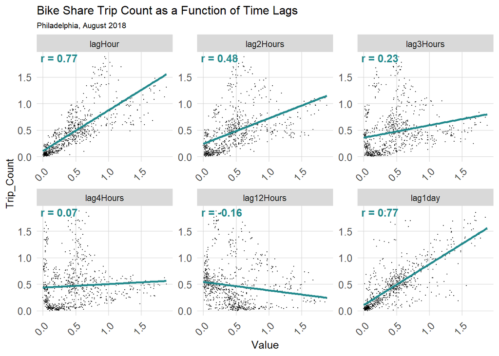

```r
ggplot(plotLags, aes(Value, Trip_Count)) +
  geom_point(size = 0.1) +
  geom_text(data = correlation.lag, aes(label = paste("r =", round(correlation, 2))),
            x=-Inf, y=Inf, vjust = 1.25, hjust = -0.1, colour="#238a8dff", fontface ="bold") +
  geom_smooth(method = "lm", se = FALSE, colour = "#238a8dff") +
  facet_wrap(~Variable, ncol = 3, scales = "free") +
  labs(title = "Bike Share Trip Count as a Function of Time Lags",
       subtitle = "Philadelphia, August 2018") + plotTheme
```

## Trip Count Spatial Autocorrelation

Since the bike trip data is joined to the census tracts, visualizing the trip count aggregated by census tract may be useful for understanding the spatiality of demand for bikes in the city.

NOTE: Not all Census Tracts in Philadelphia have an Indego station; the maps with Census Tracts only show those that have at least one station.

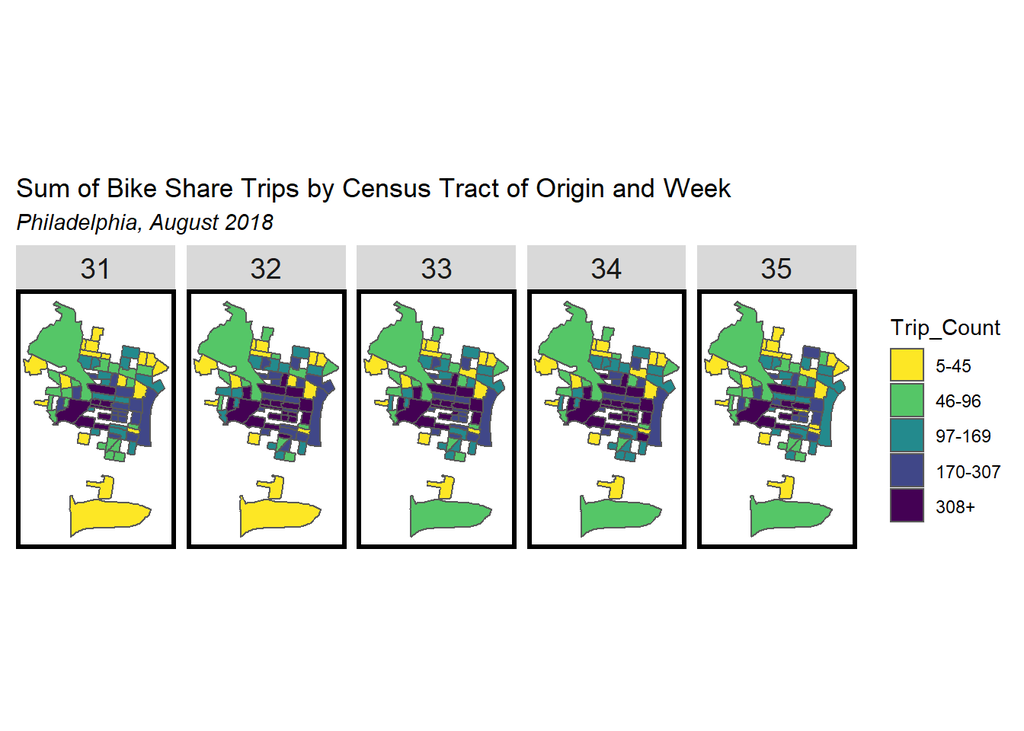

```r
tripCountTractWeek <- group_by(ride.panel, week, Origin.Tract) %>%
  summarize(Sum_Trip_Count = sum(Trip_Count)) %>%
  ungroup() %>%

  ggplot() +
    geom_sf( aes(fill = q5(Sum_Trip_Count))) +
    facet_wrap(~week, ncol = 5) +
    scale_fill_manual(values = palette5viridis,
                      labels = c("5-45", "46-96", "97-169", "170-307", "308+"),
                      name = "Trip_Count") +
    labs(title="Sum of Bike Share Trips by Census Tract of Origin and Week",
         subtitle="Philadelphia, August 2018") +
 mapTheme()

tripCountTractWeek
```

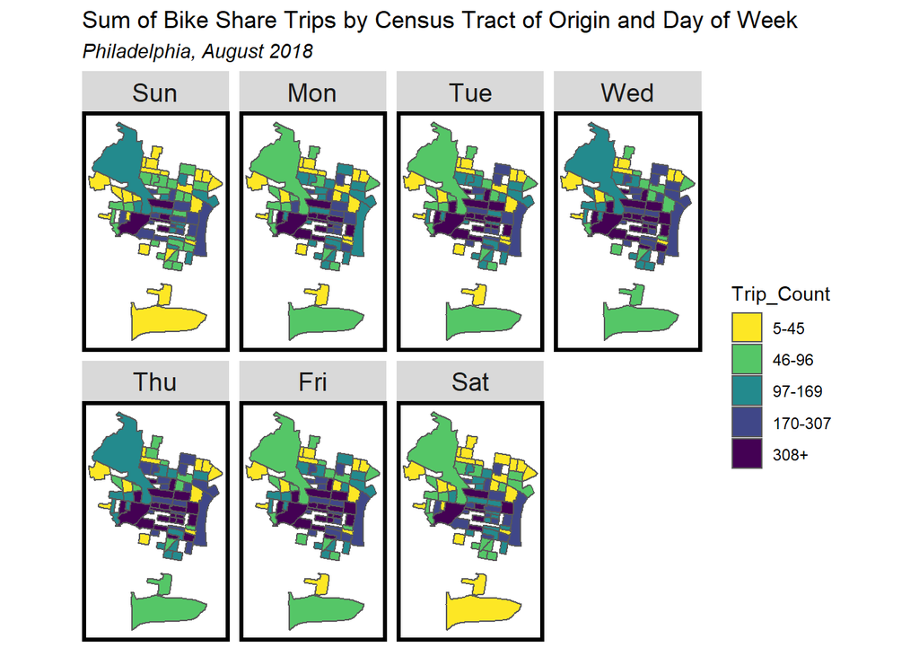

```r
tripCountTractDOTW <- group_by(ride.panel, dotw, Origin.Tract) %>%
  summarize(Sum_Trip_Count = sum(Trip_Count)) %>%
  ungroup() %>%
  ggplot() +
    geom_sf(aes(fill = q5(Sum_Trip_Count))) +
    facet_wrap(~dotw, ncol = 4) +
    scale_fill_manual(values = palette5viridis,
                      labels = c("5-45", "46-96", "97-169", "170-307", "308+"),
                      name = "Trip_Count") +
    labs(title="Sum of Bike Share Trips by Census Tract of Origin and Day of Week",
         subtitle="Philadelphia, August 2018") + mapTheme()

tripCountTractDOTW
```

## Distance to Center City

The maps above show that there are concentrations of bike trips in Census Tracts in the center of the city, so a feature is engineered for Euclidian distance to the center (as a centroid) of the Center City neighborhood.

```r
ride.panel %>% st_as_sf(coords = c("start_lon", "start_lat"), crs = 4326, agr = "constant")

nhoods <- st_read("https://raw.githubusercontent.com/azavea/geo-data/master/Neighborhoods_Philadelphia/Neighborhoods_Philadelphia.geojson") %>% st_transform(st_crs(ride.panel))

ccPoint <-
  filter(nhoods, name == "CENTER_CITY") %>%
  st_centroid()

ride.panel$ccDistance =
  st_distance(st_centroid(ride.panel),ccPoint)
#%>% as.numeric()
```

## Time of Day

It seems that including the `time_of_day` variable as a permanent part of the dataset may help with bolstering predictive power of the model later on; so it is created again as a permanent feature and joined to `ride.panel`. The four bins are Overnight, AM Rush, Mid-Day, and PM Rush.

```r
ride.panel <- ride.panel %>%
    mutate(hour = hour(interval60),
      time_of_day = case_when(hour(interval60) < 7 | hour(interval60) > 18 ~ "Overnight",
                                 hour(interval60) >= 7 & hour(interval60) < 10 ~ "AM Rush",
                                 hour(interval60) >= 10 & hour(interval60) < 15 ~ "Mid-Day",
                                 hour(interval60) >= 15 & hour(interval60) <= 18 ~ "PM Rush"))
```

## Space/Time Correlation

To visualize both the space and the time correlations simultaneously, two animated gifs help visualize these dependencies in the city. They both use bike share trip data from one Monday - August 13, 2018 - over 15 minute intervals. The first one groups the bike trip data by census tract, adding up the total number of trips for all of the stations in each tract. The second shows the bike trip data for each station specifically. In both cases, the animations show a concentration of trips in the center of the city.

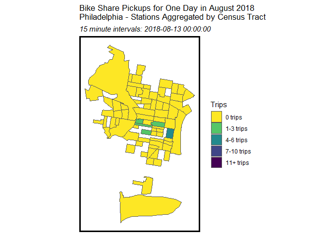

```r
week33 <-
  filter(bikeTrips_census, week == 33 & dotw == "Mon")

week33.panel <-
  expand.grid(
    interval15 = unique(week33$interval15),
    Origin.Tract = unique(bikeTrips_census$Origin.Tract))

ride.animation.data_tract <-
  mutate(week33, Trip_Counter = 1) %>%
    right_join(week33.panel) %>%
    group_by(interval15, Origin.Tract) %>%
    summarize(Trip_Count = sum(Trip_Counter, na.rm=T)) %>%
    ungroup() %>%
    left_join(phillyTracts, by=c("Origin.Tract" = "GEOID")) %>%
    st_sf() %>%
    mutate(Trips = case_when(Trip_Count == 0 ~ "0 trips",
                             Trip_Count > 0 & Trip_Count <= 3 ~ "1-3 trips",
                             Trip_Count > 3 & Trip_Count <= 6 ~ "4-6 trips",
                             Trip_Count > 6 & Trip_Count <= 10 ~ "7-10 trips",
                             Trip_Count > 10 ~ "11+ trips")) %>%
    mutate(Trips  = fct_relevel(Trips, "0 trips","1-3 trips","4-6 trips",
                                       "7-10 trips","11+ trips"))

rideshare_animation_tract <-
  ggplot() +
    geom_sf(data = ride.animation.data_tract, aes(fill = Trips)) +
    scale_fill_manual(values = palette5viridis) +
    labs(title = "Bike Share Pickups for One Day in August 2018 \nPhiladelphia - Stations Aggregated by Census Tract",
         subtitle = "15 minute intervals: {current_frame}") + mapTheme()+
    transition_manual(interval15)

animate(rideshare_animation_tract, duration=20, renderer = gifski_renderer())
```

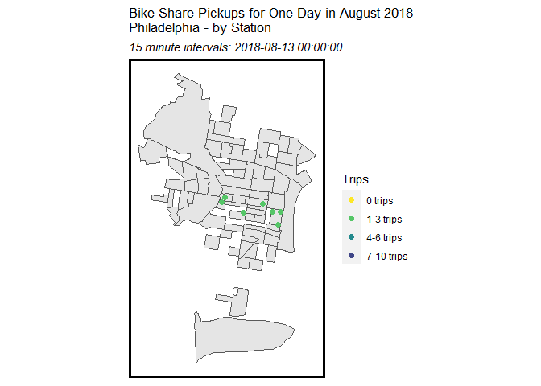

```r
# animation by bikeshare station
week33_2 <-
  filter(bikeTrips_census, week == 33 & dotw == "Mon")

week33.panel_2 <-
  expand.grid(
    interval15 = unique(week33_2$interval15),
    start_station = unique(bikeTrips2$start_station))

ride.animation.data <-
  mutate(week33_2, Trip_Counter = 1) %>%
    right_join(week33.panel_2) %>%
    group_by(interval15, start_station, start_lat, start_lon) %>%
    summarize(Trip_Count = sum(Trip_Counter, na.rm=T)) %>%
    ungroup() %>%
    mutate(Trips = case_when(Trip_Count == 0 ~ "0 trips",
                             Trip_Count > 0 & Trip_Count <= 3 ~ "1-3 trips",
                             Trip_Count > 3 & Trip_Count <= 6 ~ "4-6 trips",
                             Trip_Count > 6 & Trip_Count <= 10 ~ "7-10 trips",
                             Trip_Count > 10 ~ "11+ trips")) %>%
    mutate(Trips  = fct_relevel(Trips, "0 trips","1-3 trips","4-6 trips",
                                       "7-10 trips","11+ trips"))

rideshare_animation <-
  ggplot() +
    geom_sf(data=ride.animation.data_tract) +
    geom_point(data = ride.animation.data, aes(x = start_lon, y = start_lat, color = Trips), size=2)+
    scale_color_manual(values = palette5viridis) +
    labs(title = "Bike Share Pickups for One Day in August 2018 \nPhiladelphia - by Station",
         subtitle = "15 minute intervals: {current_frame}") + mapTheme() +
    transition_manual(interval15)

animate(rideshare_animation, duration=20, renderer = gifski_renderer())
```

## Weather

The three time series charts below show precipitation, wind speed, and temperature throughout August 2018 in Philadelphia. It is clear that the middle of the month saw the greatest amount of precipitation (given the month, the assumption is that it was rain and not snow), whereas the end of the month was fairly dry. The temperature data shows there was a bit of a cold spike towards the end of August, but it is not related to the precipitation peak, or fluctuations in wind speed. In the modeling portion of this analysis, these variables will be incorporated to see if they improve the predictive power or not.

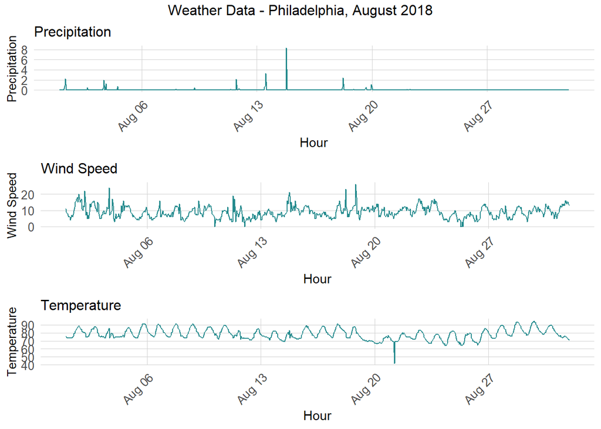

```r
grid.arrange(
  ggplot(weather.Panel, aes(interval60,Precipitation)) + geom_line(color="#238a8dff") +
  labs(title="Precipitation", x="Hour", y="Precipitation") + plotTheme,
  ggplot(weather.Panel, aes(interval60,Wind_Speed)) + geom_line(color="#238a8dff") +
    labs(title="Wind Speed", x="Hour", y="Wind Speed") + plotTheme,
  ggplot(weather.Panel, aes(interval60,Temperature)) + geom_line(color="#238a8dff") +
    labs(title="Temperature", x="Hour", y="Temperature") + plotTheme,
  top="Weather Data - Philadelphia, August 2018")
```

To get a better sense of the relationship between precipitation and bike ridership, the histogram below shows the mean number of trips in August when precipitation occurs and does not occur. While the mean is higher for no precipitation, the difference is not drastic enough to show a huge effect, especially given the limited amount of precipitation throughout the month.

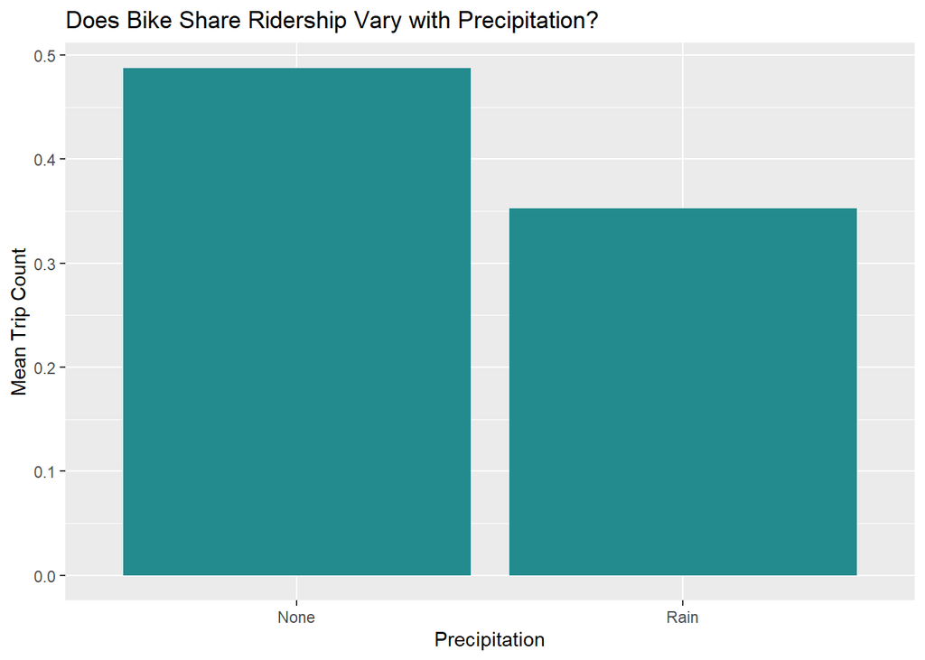

```r
st_drop_geometry(ride.panel) %>%
  group_by(interval60) %>%
  summarize(Trip_Count = mean(Trip_Count),
            Precipitation = first(Precipitation)) %>%
  mutate(isPrecip = ifelse(Precipitation > 0,"Rain", "None")) %>%
  group_by(isPrecip) %>%
  summarize(Mean_Trip_Count = mean(Trip_Count)) %>%
    ggplot(aes(isPrecip, Mean_Trip_Count)) + geom_bar(stat = "identity", fill = "#238a8dff") +
      labs(title="Does Bike Share Ridership Vary with Precipitation?",
           x="Precipitation", y="Mean Trip Count")
```

The temperature variable is then explored to look at the relationship between mean trip count and temperature. These plots show trip count as a function of temperature by week. All five weeks in the panel show that bike share increases as the temperature increases. However, this does not take into account temperature per time of day - overnight and morning periods are likely to be colder than mid-day hours, for example. As shown in previous visualizations, the number of trips increase as the day goes on - specifically in the morning and the evenings compared to overnight periods. When developing the models, it is important to control for time when looking at the predictive power of the temperature variable.

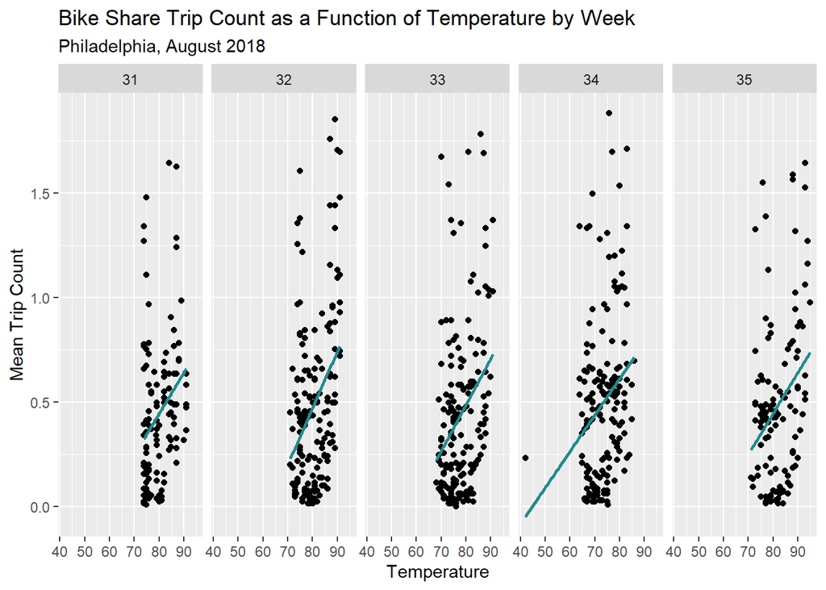

```r
st_drop_geometry(ride.panel) %>%
  group_by(interval60) %>%
  summarize(Trip_Count = mean(Trip_Count),
            Temperature = first(Temperature)) %>%
  mutate(week = week(interval60)) %>%
  ggplot(aes(Temperature, Trip_Count)) +
    geom_point() + geom_smooth(method = "lm", se= FALSE, colour = "#238a8dff") +
    facet_wrap(~week, ncol=8) +
    labs(title="Bike Share Trip Count as a Function of Temperature by Week",
         subtitle="Philadelphia, August 2018",
         x="Temperature", y="Mean Trip Count")
```

# Modeling and Testing

In this section, linear models are created and tested on partitioned dataset. Once a model is chosen, the errors are explored. Then, the chosen model is cross-validated using the “leave-one-group-out” method, based on bike station. The cross-validation uses the full five-week panel of data.

## Split data to train and test

The five-week data is split into a training set (first three weeks) and a test set (last two weeks) of the August 2018 bike trips.

```r
ride.Train <- filter(ride.panel, week < 34)
ride.Test <- filter(ride.panel, week >= 34)
```

## Bike Trip Count Serial Autocorrelation

This plot shows the bike trips by hour, separated by color for the training and testing data. There are similar peaks and troughs in both sets.

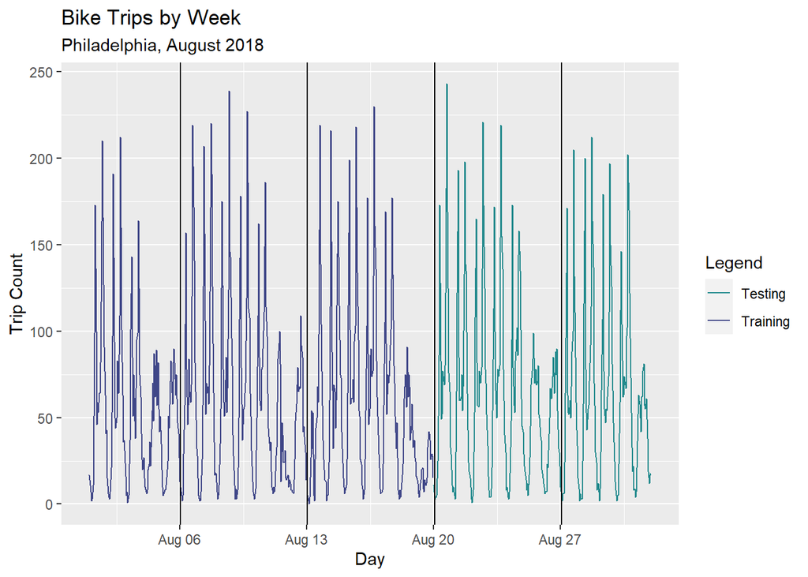

```r
mondays <-
  mutate(ride.panel,
         monday = ifelse(dotw == "Mon" & hour(interval60) == 1,
                         interval60, 0)) %>%
  filter(monday != 0)

rbind(
  mutate(ride.Train, Legend = "Training"),
  mutate(ride.Test, Legend = "Testing")) %>%
    group_by(Legend, interval60) %>%
      summarize(Trip_Count = sum(Trip_Count)) %>%
      ungroup() %>%
      ggplot(aes(interval60, Trip_Count, colour = Legend)) + geom_line() +
        scale_colour_manual(values = palette2) +
        geom_vline(data = mondays, aes(xintercept = monday)) +
        labs(title="Bike Trips by Week",
        subtitle="Philadelphia, August 2018",
             x="Day", y="Trip Count")
```

## Running Models

After exploring Poisson regression, Ordinary Least Squares (OLS) regression is better for this data. There are many data points in this month of trips, so it should work well for accuracy. Here, four linear models are created using the `lm` function and the training data `ride.Train`.

```r
reg1 <-
  lm(Trip_Count ~  hour(interval60) + dotw + Temperature,  data=ride.Train)

reg2 <-
  lm(Trip_Count ~  start_station + dotw + Temperature,  data=ride.Train)

reg3 <-
  lm(Trip_Count ~  start_station + hour(interval60) + dotw + time_of_day + passholder_type + Temperature + Precipitation,
     data=ride.Train)

reg4 <-
  lm(Trip_Count ~  start_station + hour(interval60) + Temperature  + dotw  + time_of_day + trip_route_category + lagHour + lag2Hours + lag12Hours + lag1day + ccDistance,
     data=ride.Train)
```

## Predicting for Test Data

Next, a nested dataframe is created to house the test data by week. The `purr` package is used here, which contains functions to loop through the nested data and compare across model specifications.

```r
library(purrr)
ride.Test.weekNest <-
  ride.Test %>%
  nest(-week)

model_pred <- function(dat, fit){
   pred <- predict(fit, newdata = dat)}
```

```r
week_predictions <-
  ride.Test.weekNest %>%
    mutate(A = map(.x = data, fit = reg1, .f = model_pred),
           B = map(.x = data, fit = reg2, .f = model_pred),
           C = map(.x = data, fit = reg3, .f = model_pred),
           D = map(.x = data, fit = reg4, .f = model_pred)) %>%
    gather(Regression, Prediction, -data, -week) %>%
    mutate(Observed = map(data, pull, Trip_Count),
           Absolute_Error = map2(Observed, Prediction,  ~ abs(.x - .y)),
           MAE = map_dbl(Absolute_Error, mean, na.rm = TRUE),
           sd_AE = map_dbl(Absolute_Error, sd, na.rm = TRUE))

#week_predictions
```

## Error Metrics

The bars below shows mean absolute errors by each of the models by week. Model D, the one selected, has lower errors compared to the others for each week. Regressing by `Trip_Count`, the chosen model accounts for the following:

- Time lag features (`lagHour`, `lag2Hours`, `lag12Hours`, and `lag1day`)
- Day of the week (`dotw`)
- Station of origin (`start_station`)
- Hour (`hour(interval60`)
- Distance to the centroid of Center City (`ccDistance`)
- Trip route - one way vs. round trip (`trip_route_category`)
- Categorical time of day (`time_of_day`)

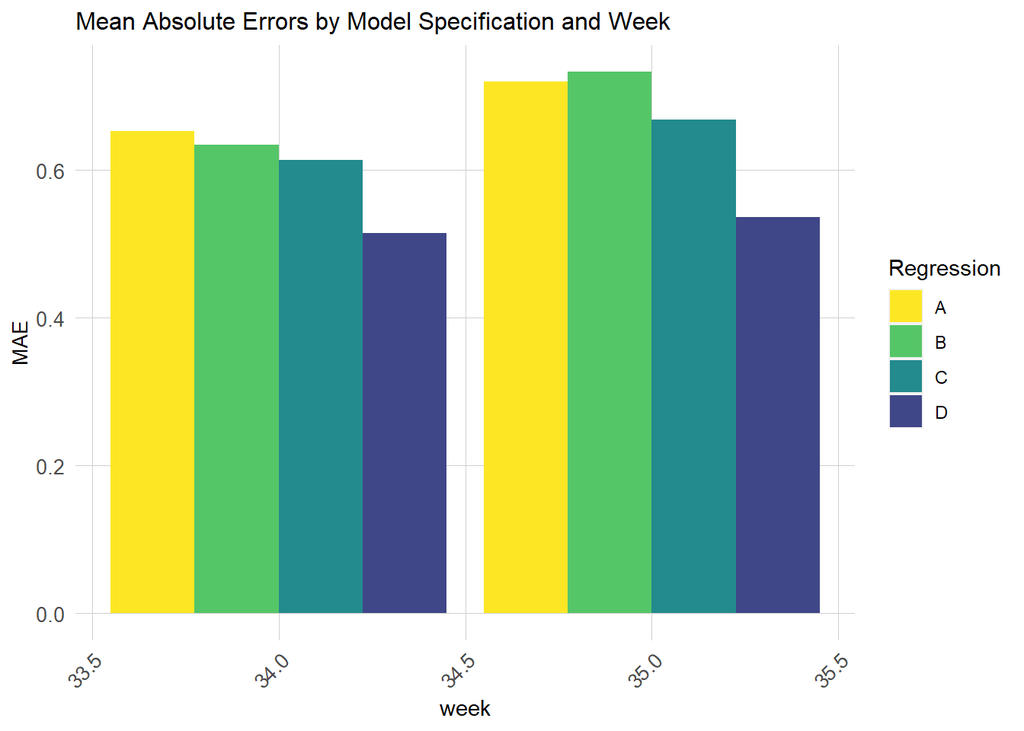

```r
week_predictions %>%
  dplyr::select(week, Regression, MAE) %>%
  gather(Variable, MAE, -Regression, -week) %>%
  ggplot(aes(week, MAE)) +
    geom_bar(aes(fill = Regression), position = "dodge", stat="identity") +
    scale_fill_manual(values = palette5viridis) +
    labs(title = "Mean Absolute Errors by Model Specification and Week") +
  plotTheme
```

The charts below show the predicted and observed bike share trips from the stations for the last two weeks in August 2018. Again, model “D” shows a closer match between the predictions and what was actually observed. However, it should be noted that in several cases, the observations are still higher than the peaks, indicating that there are likely other factors at play influencing demand that are not accounted for in the models.

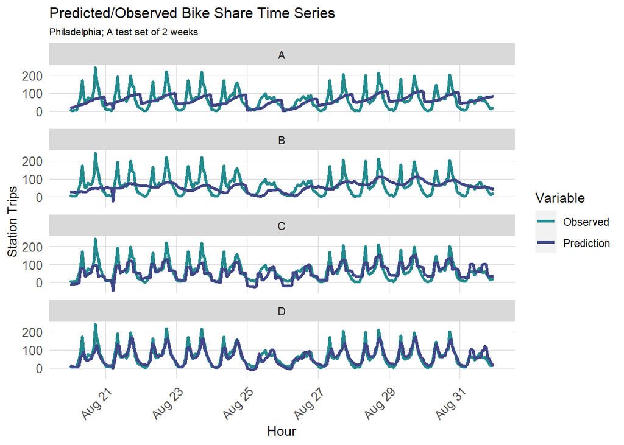

```r
week_predictions %>%
    mutate(interval60 = map(data, pull, interval60),
           start_station = map(data, pull, start_station)) %>%
    dplyr::select(interval60, start_station, Observed, Prediction, Regression) %>%
    unnest() %>%
    gather(Variable, Value, -Regression, -interval60, -start_station) %>%
    group_by(Regression, Variable, interval60) %>%
    summarize(Value = sum(Value)) %>%
    ggplot(aes(interval60, Value, colour=Variable)) +
      geom_line(size = 1.1) +
      scale_colour_manual(values = palette2) +
      facet_wrap(~Regression, ncol=1) +
      labs(title = "Predicted/Observed Bike Share Time Series", subtitle = "Philadelphia; A test set of 2 weeks",  x = "Hour", y= "Station Trips") +
      plotTheme
```

Using the selected model (D), the map below shows mean absolute errors by station. It seems like the errors are higher when concentrated towards the middle of the city, which is interesting because a variable accounting for this distance to Center City feature is included. Perhaps distance to one point is not enough predictive power here, and a collection of points of interest for other amenities would be helpful. Regardless, in future iterations of this model, it is recommended to do additional feature engineering to understand the other factors influencing ride share demand in Center City.

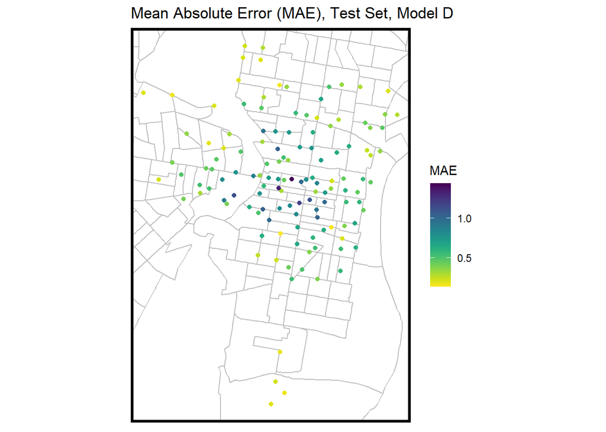

```r
week_predictions %>%
    mutate(interval60 = map(data, pull, interval60),
           start_station = map(data, pull, start_station),
           start_lat = map(data, pull, start_lat),
           start_lon = map(data, pull, start_lon)) %>%
    select(interval60, start_station, start_lon, start_lat, Observed, Prediction, Regression) %>%
    unnest() %>%
  filter(Regression == "D") %>%
  group_by(start_station, start_lon, start_lat) %>%
  summarize(MAE = mean(abs(Observed-Prediction), na.rm = TRUE))%>%
ggplot(.)+
  geom_sf(data = phillyCensus, color = "grey", fill = "transparent")+
  geom_point(aes(x = start_lon, y = start_lat, color = MAE),
             fill = "transparent")+
  scale_colour_viridis(direction = -1,
  discrete = FALSE, option = "D")+
  ylim(min(bikeTrips_census$start_lat), max(bikeTrips_census$start_lat))+
  xlim(min(bikeTrips_census$start_lon), max(bikeTrips_census$start_lon))+
  labs(title="Mean Absolute Error (MAE), Test Set, Model D")+
  mapTheme()
```

## Space-Time Error Evaluation

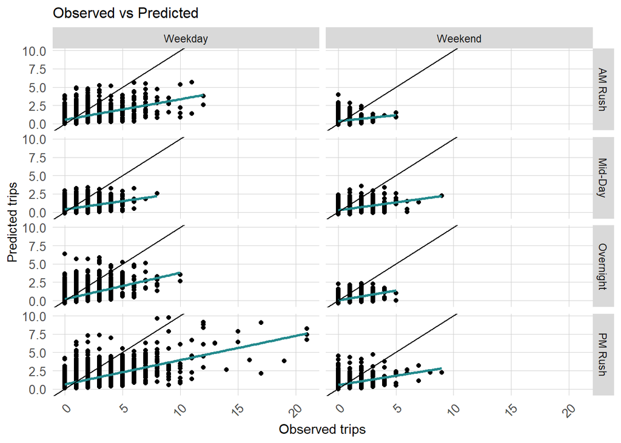

```r
week_predictions %>%
    mutate(interval60 = map(data, pull, interval60),
           start_station = map(data, pull, start_station),
           start_lat = map(data, pull, start_lat),
           start_lon = map(data, pull, start_lon),
           dotw = map(data, pull, dotw)) %>%
    select(interval60, start_station, start_lon,
           start_lat, Observed, Prediction, Regression,
           dotw) %>%
    unnest() %>%
  filter(Regression == "D")%>%
  mutate(weekend = ifelse(dotw %in% c("Sun", "Sat"), "Weekend", "Weekday"),
         time_of_day = case_when(hour(interval60) < 7 | hour(interval60) > 18 ~ "Overnight",
                                 hour(interval60) >= 7 & hour(interval60) < 10 ~ "AM Rush",
                                 hour(interval60) >= 10 & hour(interval60) < 15 ~ "Mid-Day",
                                 hour(interval60) >= 15 & hour(interval60) <= 18 ~ "PM Rush"))%>%
  ggplot()+
  geom_point(aes(x= Observed, y = Prediction))+
    geom_smooth(aes(x= Observed, y= Prediction), method = "lm", se = FALSE, color = "#238a8dff")+
    geom_abline(slope = 1, intercept = 0)+
  facet_grid(time_of_day~weekend)+
  labs(title="Observed vs Predicted",
       x="Observed trips",
       y="Predicted trips")+
  plotTheme
```

Visualizing these errors on a map helps investigate this further. This shows that in the PM rush, for instance, during the week when underpredicting, the errors are higher. This is especially true in the center of the city.

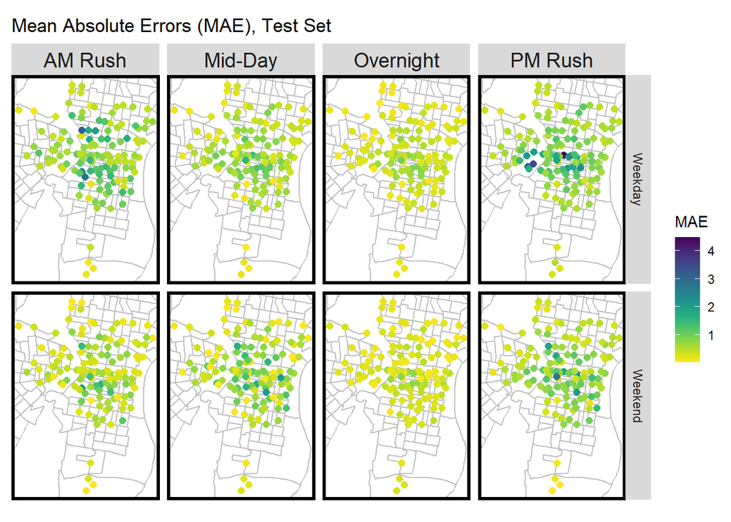

```r
week_predictions %>%
    mutate(interval60 = map(data, pull, interval60),
           start_station = map(data, pull, start_station),
           start_lat = map(data, pull, start_lat),
           start_lon = map(data, pull, start_lon),
           dotw = map(data, pull, dotw) ) %>%
    select(interval60, start_station, start_lon,
           start_lat, Observed, Prediction, Regression,
           dotw) %>%
    unnest() %>%
  filter(Regression == "D")%>%
  mutate(weekend = ifelse(dotw %in% c("Sun", "Sat"), "Weekend", "Weekday"),
         time_of_day = case_when(hour(interval60) < 7 | hour(interval60) > 18 ~ "Overnight",
                                 hour(interval60) >= 7 & hour(interval60) < 10 ~ "AM Rush",
                                 hour(interval60) >= 10 & hour(interval60) < 15 ~ "Mid-Day",
                                 hour(interval60) >= 15 & hour(interval60) <= 18 ~ "PM Rush")) %>%
  group_by(start_station, weekend, time_of_day, start_lon, start_lat) %>%
  summarize(MAE = mean(abs(Observed-Prediction), na.rm = TRUE))%>%
  ggplot(.)+
  geom_sf(data = phillyCensus, color = "grey", fill = "transparent")+
  geom_point(aes(x = start_lon, y = start_lat, color = MAE),
             fill = "transparent", size = 2)+
  scale_colour_viridis(direction = -1,
  discrete = FALSE, option = "D")+
  ylim(min(bikeTrips_census$start_lat), max(bikeTrips_census$start_lat))+
  xlim(min(bikeTrips_census$start_lon), max(bikeTrips_census$start_lon))+
  facet_grid(weekend~time_of_day)+
  labs(title="Mean Absolute Errors (MAE), Test Set")+
  mapTheme()
```

Focusing on the evening commute (PM rush), these plots show how the model performs in the context of the socioeconomic variables. Median Income does not appear to have much of a correlation. However, looking at percent of those taking public transportation, as the percent increases, the error for bike trips decreases. This indicates that the model predicts better for the bike share stations in Census Tracts where more people take public transit to work. Furthermore, as the percentage of population that is White in a Census Tract increases, the MAE for trips also increases, indicating that in majority-white areas, it may be harder to predict demand for bike share ridership.

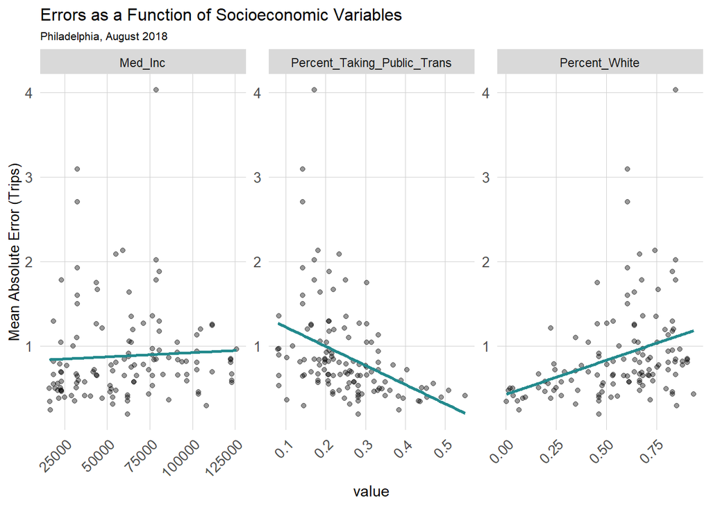

```r
week_predictions %>%
    mutate(interval60 = map(data, pull, interval60),
           start_station = map(data, pull, start_station),
           start_lat = map(data, pull, start_lat),
           start_lon = map(data, pull, start_lon),
           dotw = map(data, pull, dotw),
           Percent_Taking_Public_Trans = map(data, pull, Percent_Taking_Public_Trans),
           Med_Inc = map(data, pull, Med_Inc),
           Percent_White = map(data, pull, Percent_White)) %>%
    select(interval60, start_station, start_lon,
           start_lat, Observed, Prediction, Regression,
           dotw, Percent_Taking_Public_Trans, Med_Inc, Percent_White) %>%
    unnest() %>%
  filter(Regression == "D")%>%
  mutate(weekend = ifelse(dotw %in% c("Sun", "Sat"), "Weekend", "Weekday"),
         time_of_day = case_when(hour(interval60) < 7 | hour(interval60) > 18 ~ "Overnight",
                                 hour(interval60) >= 7 & hour(interval60) < 10 ~ "AM Rush",
                                 hour(interval60) >= 10 & hour(interval60) < 15 ~ "Mid-Day",
                                 hour(interval60) >= 15 & hour(interval60) <= 18 ~ "PM Rush")) %>%
  filter(time_of_day == "PM Rush") %>%
  group_by(start_station, Percent_Taking_Public_Trans, Med_Inc, Percent_White) %>%
  summarize(MAE = mean(abs(Observed-Prediction), na.rm = TRUE))%>%
  gather(-start_station, -MAE, key = "variable", value = "value")%>%
  ggplot(.)+
  geom_point(aes(x = value, y = MAE), alpha = 0.4)+
  geom_smooth(aes(x = value, y = MAE), method = "lm", se= FALSE, color="#238A8DFF")+
  facet_wrap(~variable, scales = "free")+
  labs(title="Errors as a Function of Socioeconomic Variables",
       subtitle="Philadelphia, August 2018",
       y="Mean Absolute Error (Trips)")+
  plotTheme
```

## Cross Validation

```r
#load the r cross validate function

crossValidate <- function(dataset, id, dependentVariable, indVariables) {

allPredictions <- data.frame()
cvID_list <- unique(dataset[[id]])

for (i in cvID_list) {

  thisFold <- i
  cat("This hold out fold is", thisFold, "\n")

  fold.train <- filter(dataset, dataset[[id]] != thisFold) %>% as.data.frame() %>%
                dplyr::select(start_station, week, interval60, indVariables, dependentVariable, start_lat, start_lon)
  fold.test  <- filter(dataset, dataset[[id]] == thisFold) %>% as.data.frame() %>%
                dplyr::select(start_station, week, interval60, indVariables, dependentVariable, start_lat, start_lon)

regression <-
  lm(Trip_Count ~  start_station + hour(interval60) + Temperature  + dotw  + time_of_day + trip_route_category +
                   lagHour + lag2Hours + lag12Hours + lag1day + ccDistance,
     data=ride.panel)

  thisPrediction <-
    mutate(fold.test, Prediction = predict(regression, fold.test, type = "response"))

  allPredictions <-
    rbind(allPredictions, thisPrediction)

  }
  return(allPredictions)
}
```

```r
# reg.vars
reg.vars <- c("start_station", "interval60", "dotw", "Temperature", "lagHour", "lag2Hours",
              "lag12Hours", "lag1day", "ccDistance", "time_of_day", "trip_route_category")

# crossValidate
reg.SpatialCV <- crossValidate(
  dataset = ride.panel,
  id = "start_station",
  dependentVariable = "Trip_Count",
  indVariables = reg.vars) %>%
  dplyr::select(cvID = start_station, Trip_Count, Prediction, interval60, dotw, start_lat, start_lon, ccDistance,trip_route_category, time_of_day)
```

The histogram below shows the distribution of errors for the LOGO cross-validation. There are a few errors that are much higher than others, but for the most part, the distribution hovers between 0 and 0.1. The higher errors are likely skewing the error distribution.

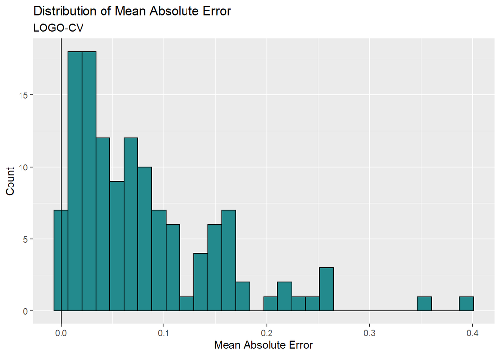

```r
# reg summary
reg.summary <-
    mutate(reg.SpatialCV, Error = Prediction - Trip_Count,
                          Regression = "LOGO-CV")
# calculate errors
error_by_fold <-
  reg.summary %>%
    group_by(cvID, start_lon, start_lat) %>%
    summarize(Mean_Error = mean(Prediction - Trip_Count, na.rm = T),
              MAE = mean(abs(Mean_Error), na.rm = T),
              SD_MAE = mean(abs(Mean_Error), na.rm = T)) %>%
  ungroup()

## plot histogram of OOF (out of fold) errors
error_by_fold %>%
  ggplot(aes(MAE)) +
    geom_histogram(bins = 30, colour="black", fill = "#238A8DFF") +
    geom_vline(xintercept = 0)  +
    labs(title="Distribution of Mean Absolute Error", subtitle = "LOGO-CV",
         x="Mean Absolute Error", y="Count")
```

To visualize these mean absolute errors by station, they are plotted on the map below. The higher errors are clustered around the center of the city, again showing that the model does not generalize as well to Center City and surrounding areas as it does to stations in West Philadelphia (and also a bit to the south).

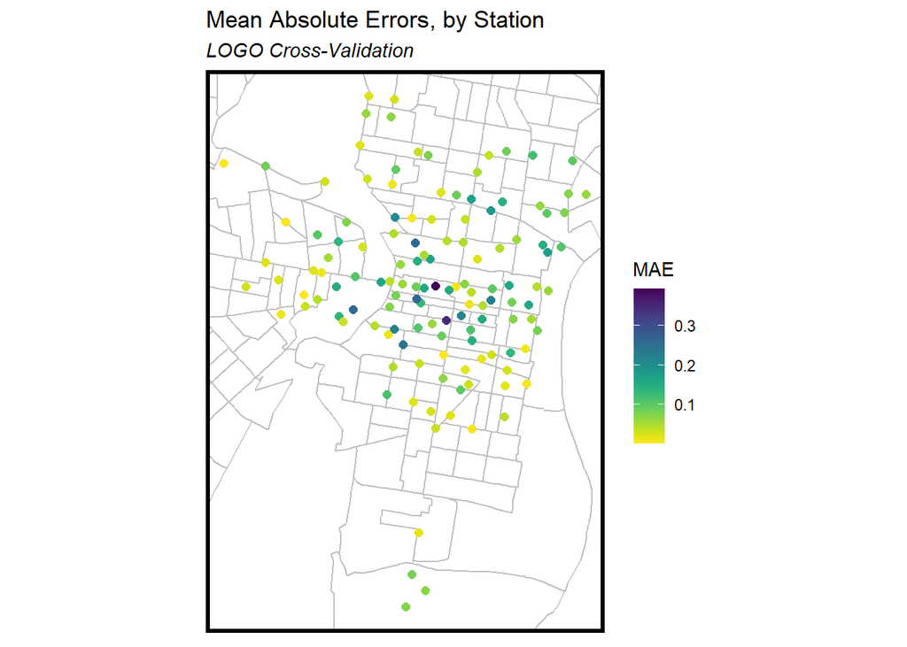

```r
error_by_fold_for_map <-
  reg.summary %>%
    group_by(cvID, start_lon, start_lat) %>%
  summarize(Mean_Error = mean(Prediction - Trip_Count, na.rm = T),
              MAE = mean(abs(Mean_Error), na.rm = T),
              SD_MAE = mean(abs(Mean_Error), na.rm = T)) %>% ungroup() %>%
  st_as_sf(coords = c("start_lon", "start_lat"), crs = 4326, agr = "constant")

  ggplot()+
  geom_sf(data = phillyCensus, color = "grey", fill = "transparent")+
  geom_sf(data=error_by_fold_for_map, aes(color = MAE),
             fill = "transparent", size = 2)+
  scale_colour_viridis(direction = -1,
  discrete = FALSE, option = "D")+
  ylim(min(bikeTrips_census$start_lat), max(bikeTrips_census$start_lat))+
  xlim(min(bikeTrips_census$start_lon), max(bikeTrips_census$start_lon))+
  labs(title="Mean Absolute Errors, by Station",
  subtitle="LOGO Cross-Validation")+
  mapTheme()
```

# Conclusion

To improve this model, additional feature engineering to better pinpoint the factors affecting ridership is recommended. This is especially pertinent for the Center City area, where there may be some additional ridership patterns, demographics, or amenities at play. While the time lag variables did add some predictive power to the model, the distance to the center of the Center City neighborhood hardly influenced the model. In short, it is not recommended to use this algorithm to re-balance the bike share allocation based on ridership demand until the predictive power improves. Specifically, further investigation into the nuances of Center City ridership - beyond what already exists in the Indego dataset and time lag features - is warranted.